# Latihan Pertemuan 7 : Diagnostik Model & Peramalan - Adinda Shabrina Putri Salsabila

#### Uji Formal

```r
#1) Sisaan Menyebar Normal
ks.test(sisaan.da,"pnorm")  #tak tolak H0 > sisaan menyebar normal
```

```
##
##  Exact one-sample Kolmogorov-Smirnov test
##
## data:  sisaan.da
## D = 0.53061, p-value = 4.441e-16
## alternative hypothesis: two-sided
```

Selain dengan eksplorasi, asumsi tersebut dapat diuji menggunakan uji formal. Pada tahapan ini uji formal yang digunakan untuk normalitas adalah uji Kolmogorov-Smirnov (KS). Hipotesis pada uji KS adalah sebagai berikut.

$H_0$ : Sisaan menyebar normal

$H_1$ : Sisaan tidak menyebar normal

Berdasarkan uji KS tersebut, didapat *p-value* sebesar 4.441e-16 yang kurang dari taraf nyata 5% sehingga tolak $H_0$ dan menandakan bahwa sisaan tidak menyebar normal. Hal ini sesuai dengan hasil eksplorasi menggunakan plot kuantil-kuantil normal.

```r
#2) Sisaan saling bebas/tidak ada autokorelasi
Box.test(sisaan.da, type = "Ljung")  #tak tolak H0 > sisaan saling bebas
```

```
##
##  Box-Ljung test
##
## data:  sisaan.da
## X-squared = 0.14467, df = 1, p-value = 0.7037
```

Selanjutnya akan dilakukan uji formal untuk kebebasan sisaan menggunakan uji Ljung-Box. Hipotesis yang digunakan adalah sebagai berikut.

$H_0$ : Sisaan saling bebas

$H_1$ : Sisaan tidak tidak saling bebas

Berdasarkan uji Ljung-Box tersebut, didapat *p-value* sebesar 0.7037 yang lebih besar dari taraf nyata 5% sehingga tak tolak $H_0$ dan menandakan bahwa sisaan saling bebas.

```r
#3) Sisaan homogen
Box.test((sisaan.da)^2, type = "Ljung")  #tak tolak H0 > sisaan homogen
```

```
##
##  Box-Ljung test
##
## data:  (sisaan.da)^2
## X-squared = 0.69256, df = 1, p-value = 0.4053
```

Hipotesis yang digunakan untuk uji kehomogenan ragam adalah sebagai berikut.

$H_0$ : Ragam sisaan homogen

$H_1$ : Ragam sisaan tidak homogen

```r
#4) Nilai tengah sisaan sama dengan nol
t.test(sisaan.da, mu = 0, conf.level = 0.95)  #tak tolak h0 > nilai tengah sisaan sama dengan 0
```

```
##
##  One Sample t-test
##
## data:  sisaan.da
## t = 0.23724, df = 97, p-value = 0.813
## alternative hypothesis: true mean is not equal to 0
## 95 percent confidence interval:
##  -599.0881  761.7566
## sample estimates:
## mean of x
##  81.33425
```

Terakhir, dengan uji-t, akan dicek apakah nilai tengah sisaan sama dengan nol. Hipotesis yang diujikan sebagai berikut.

$H_0$ : nilai tengah sisaan sama dengan 0

$H_1$ : nilai tengah sisaan tidak sama dengan 0

Berdasarkan uji-ttersebut, didapat *p-value* sebesar 0.813 yang lebih besar dari taraf nyata 5% sehingga tak tolak $H_0$ dan menandakan bahwa nilai tengah sisaan sama dengan nol.

# Overfitting

Tahapan selanjutnya adalah overfitting dilakukan dengan menaikkan orde AR(p) dan MA(q) dari model ARIMA (1,2,2) untuk melihat apakah terdapat model lain yang lebih baik dari model saat ini. Kandidat model overfitting adalah ARIMA (2,2,2) dan ARIMA (1,2,3)

```r
model5a.ma2=Arima(cabaitrain, order=c(2,2,2),method="ML")
summary(model5a.ma2)  #1896.25
```

```
## Series: cabaitrain
## ARIMA(2,2,2)
##
## Coefficients:
##          ar1      ar2      ma1     ma2
##       0.1605  -0.0729  -1.2928  0.3174
## s.e.  0.6605   0.1569   0.6597  0.6440
##
## sigma^2 = 13496114:  log likelihood = -943.13
## AIC=1896.25   AICc=1896.91   BIC=1909.18
##
## Training set error measures:
##                    ME    RMSE      MAE      MPE     MAPE     MASE         ACF1
## Training set 370.2043 3561.79 2432.255 0.674579 4.430264 1.033856 -0.007322373
```

```r
lmtest::coeftest(model5a.ma2)  #hanya ma1 yang signifikan
```

```
##
## z test of coefficients:
##
##      Estimate Std. Error z value Pr(>|z|)
## ar1  0.160510   0.660455  0.2430  0.80798
## ar2 -0.072943   0.156924 -0.4648  0.64205
## ma1 -1.292832   0.659726 -1.9596  0.05004 .
## ma2  0.317357   0.643961  0.4928  0.62214
## ---
## Signif. codes:  0 '***' 0.001 '**' 0.01 '*' 0.05 '.' 0.1 ' ' 1
```

```r
model5b.ma2=Arima(cabaitrain, order=c(1,2,3),method="ML")
summary(model5b.ma2)  #1896.28
```

```
## Series: cabaitrain
## ARIMA(1,2,3)
##
## Coefficients:
##          ar1      ma1     ma2     ma3
##       0.0026  -1.1349  0.0678  0.0938
## s.e.  0.9658   0.9613  1.1087  0.1945
##
## sigma^2 = 13499633:  log likelihood = -943.14
## AIC=1896.28   AICc=1896.93   BIC=1909.2
##
## Training set error measures:
##                    ME     RMSE     MAE       MPE     MAPE    MASE         ACF1
## Training set 370.8077 3562.254 2432.43 0.6756461 4.429495 1.03393 -0.007072647
```

```r
lmtest::coeftest(model5b.ma2)  #seluruh parameter tidak signifikan
```

```
##
## z test of coefficients:
##
##       Estimate Std. Error z value Pr(>|z|)
## ar1  0.0025776  0.9658242  0.0027   0.9979
## ma1 -1.1348629  0.9613269 -1.1805   0.2378
## ma2  0.0678177  1.1086812  0.0612   0.9512
## ma3  0.0938431  0.1945001  0.4825   0.6295
```

```r
#model yang dipilih adalah model awal, yaitu ARIMA(1,2,2)
```

# Peramalan

Peramalan dilakukan menggunakan fungsi `forecast()` . Contoh peramalan berikut ini dilakukan untuk 40 hari ke depan.

```r
#---FORECAST---#
ramalan.da <- forecast::forecast(model5.da, h = 40)
ramalan.da
```

```
##     Point Forecast      Lo 80    Hi 80      Lo 95    Hi 95
## 101    3797.019696  -660.0864 8254.126  -3019.536 10613.58
## 102     -94.982290 -7069.7950 6879.830 -10762.038 10572.07
## 103     -70.307784 -7048.1499 6907.534 -10741.996 10601.38
## 104     -51.103537 -7030.7801 6928.573 -10725.598 10623.39
## 105     -36.156811 -7016.9444 6944.631 -10712.350 10640.04
## 106     -24.523727 -7005.9842 6956.937 -10701.746 10652.70
## 107     -15.469661 -6997.3378 6966.398 -10693.315 10662.38
## 108      -8.422852 -6990.5378 6973.692 -10686.646 10669.80
## 109      -2.938299 -6985.2028 6979.326 -10681.390 10675.51
## 110       1.330346 -6981.0248 6983.685 -10677.260 10679.92
## 111       4.652647 -6977.7574 6987.063 -10674.022 10683.33
## 112       7.238403 -6975.2048 6989.682 -10671.487 10685.96
## 113       9.250906 -6973.2125 6991.714 -10669.505 10688.01
## 114      10.817243 -6971.6583 6993.293 -10667.958 10689.59
```

[output cut: 26 more lines]

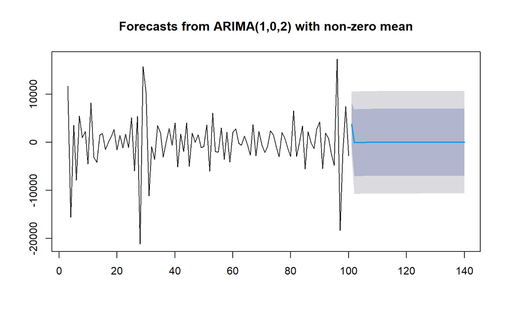

```r
data.ramalan.da <- ramalan.da$mean
plot(ramalan.da)
```

Berdasarkan hasil plot ramalan di atas, dapat dilihat bahwa ramalan ARIMA(1,2,2) cenderung stabil hingga akhir periode. Selanjutnya, dapat dicari nilai akurasi antara hasil ramalan dengan data uji sebagai berikut.

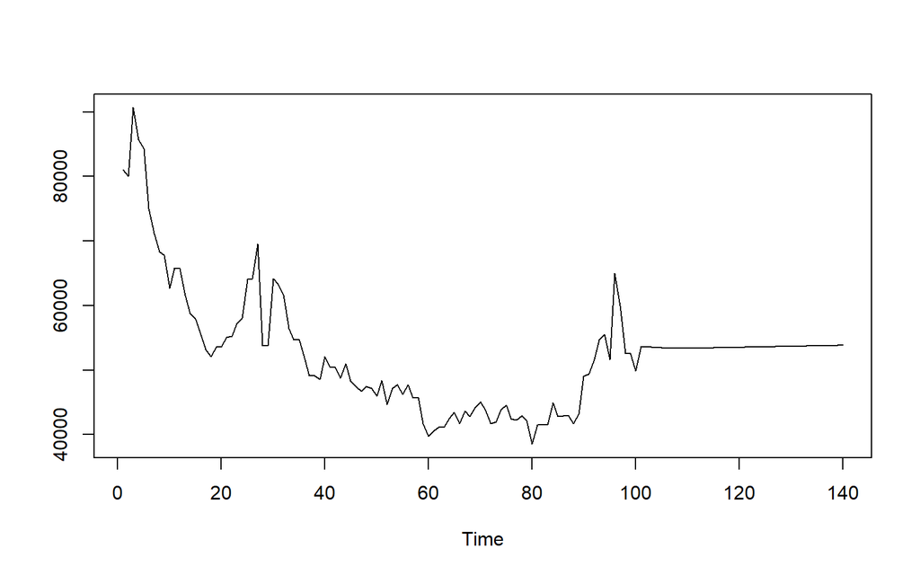

```r
pt_1 <- train.ts[100] #nilai akhir data latih
hasil.forc.Diff <- data.ramalan.da
hasil <- diffinv(hasil.forc.Diff, differences = 1) + pt_1
#has.1 sama hasilnta dengan: cumsum(c(pt_1,hasil.forc.Diff))
ts.plot(train.ts,hasil)
```

```r
perbandingan.da<-matrix(data=c(head(test.ts, n=40), hasil[-1]),
                     nrow = 40, ncol = 2)
colnames(perbandingan.da)<-c("Aktual","Hasil Forecast")
perbandingan.da
```

```
##       Aktual Hasil Forecast
##  [1,]  46640       53717.02
##  [2,]  48810       53622.04
##  [3,]  43260       53551.73
##  [4,]  42570       53500.63
##  [5,]  44760       53464.47
##  [6,]  46910       53439.95
##  [7,]  46420       53424.48
##  [8,]  44660       53416.05
##  [9,]  46420       53413.11
## [10,]  42630       53414.45
## [11,]  43430       53419.10
## [12,]  44090       53426.34
## [13,]  46210       53435.59
## [14,]  47430       53446.40
```

[output cut: 26 more lines]

```r
accuracy(ts(hasil[-1]), head(test.ts, n=40))
```

```
##                ME     RMSE      MAE      MPE     MAPE    ACF1 Theil's U
## Test set 3569.986 13646.04 11221.58 1.590991 18.28176 0.90054  2.900061
```

Hasil peramalan menunjukkan nilai MAPE sebesar 18.28176% yang berarti model ARIMA (1,2,2) termasuk dalam kategori baik. Ini berarti model tersebut cukup akurat dalam memprediksi, tetapi masih ada ruang untuk peningkatan. Model ini dapat digunakan untuk peramalan, meskipun hasilnya mungkin tidak sempurna. Jika diperlukan akurasi yang lebih tinggi, model lain atau pendekatan yang lebih kompleks dapat dipertimbangkan.